# SalesForecasting

### Sales Forecasting by Fannie Yuen

#### submitted on 2023-08-22

In this practical forecasting exercise, the following workflow will be used for sales forecasting:

- 0) Data Quality, manipulation and visualisation
- 1) Time Series Analysis
- 2) Forecasting
  - Sales per day per store (based on dataset df)
  - Sales per day (based on dataset df_agg_date)
- 3) Conclusion & Business Insights
- 4) Scalability & Productization

```python
from IPython.display import display, HTML
display(HTML("<style>.container { width:100% !important; }</style>"))
```

```python
import pandas as pd

from matplotlib import pyplot as plt
import matplotlib as mpl

from statsmodels.tsa.seasonal import seasonal_decompose
from statsmodels.tsa.arima.model import ARIMA
from statsmodels.tsa.stattools import adfuller

from sklearn.metrics import mean_squared_error
from math import sqrt

import warnings
```

```python
# ignore warnings to gather key results in jupyter notebook
warnings.filterwarnings('ignore')
```

```python
# display the first and last n rows of a dataframe
def display_n(dataframe, n):
    with pd.option_context('display.max_rows',n*2):
        display(dataframe)
```

### 0) Data Quality, Manipulation, Visualisation

```python
def time_series_plot(dataframe, y_col):
    """
    Create a time series plot

    Parameters:
    dataframe: dataframe
    y_col: target column of a dataframe to be displayed

    Return:
    a time series plot with additive trend as seasonal decomposition using moving averages
    """
    dataframe = dataframe.set_index('Date')
    sd = seasonal_decompose(dataframe[[y_col]], model = 'additive')
    plt.figure(figsize = (30, 6))
    plt.plot(dataframe[[y_col]], color = 'green', label = y_col)
    plt.plot(sd.trend, color = 'black', label = 'additive trend')
    plt.xticks(dataframe[[y_col]].index[::12], rotation = 45)
    plt.title(y_col)
    plt.legend()
```

```python
df = pd.read_csv('practical_test.csv')
```

```python
# convert column 'Date' to date format
df['Date'] = pd.to_datetime(df['Date'])
```

```python
# preview of dataset
display_n(df, 2)
```

|  | Store | Date | Sales | Store_Size | Num_Employees | Returns_Pct | Num_Customers | Pct_On_Sale | Marketing | Near_Xmas | Near_BlackFriday | Holiday | DestinationEvent | Pct_Promotional | Econ_ChangeGDP | EconJobsChange | AnnualizedCPI |
| --- | --- | --- | --- | --- | --- | --- | --- | --- | --- | --- | --- | --- | --- | --- | --- | --- | --- |
| 0 | Louisville | 2012-07-01 | 76819.40 | 20100 | 42 | 1.03 | 327 | 9.96 | July In Store Credit Card Signup Discount; In ... | 0 | 0 | No | No | 0.000047 | 0.5 | NaN | 0.02 |
| 1 | Louisville | 2012-07-02 | 78963.86 | 20100 | 21 | 0.41 | 293 | 8.65 | July In Store Credit Card Signup Discount; In ... | 0 | 0 | No | No | 0.000047 | NaN | NaN | NaN |
| ... | ... | ... | ... | ... | ... | ... | ... | ... | ... | ... | ... | ... | ... | ... | ... | ... | ... |
| 7138 | San Antonio | 2014-06-13 | 71342.17 | 17000 | 35 | 0.59 | 213 | 14.43 | Promo In Store Credit Card Signup Discount; ID... | 0 | 0 | No | No | 0.064925 | NaN | NaN | NaN |
| 7139 | San Antonio | 2014-06-14 | 74731.26 | 17000 | 34 | 0.85 | 301 | 12.90 | Promo In Store Credit Card Signup Discount; ID... | 0 | 0 | No | No | 0.064925 | NaN | -2250.0 | NaN |

7140 rows × 17 columns

This is an informative dataset with a number of columns as possible features.

In the actual forecasting scenario, some variables are not available at the time of forecasting, for instance, **Returns_Pct** and **Num_Customers** which are only available at the end of the business day. Therefore, they will be removed in this forecasting exercise.

```python
# create a dateset to aggregrate sum of Sales of all stores per Date
df_agg_date = df.groupby('Date').agg('sum').sort_values(by = 'Date').reset_index()
display_n(df_agg_date, 2)
```

|  | Date | Sales | Store_Size | Num_Employees | Returns_Pct | Num_Customers | Pct_On_Sale | Near_Xmas | Near_BlackFriday | Pct_Promotional | Econ_ChangeGDP | EconJobsChange | AnnualizedCPI |
| --- | --- | --- | --- | --- | --- | --- | --- | --- | --- | --- | --- | --- | --- |
| 0 | 2012-07-01 | 646521.78 | 169100 | 342 | 10.66 | 2754 | 105.26 | 0 | 0 | 0.000471 | 5.0 | 0.0 | 0.2 |
| 1 | 2012-07-02 | 664569.84 | 169100 | 194 | 4.23 | 2465 | 91.42 | 0 | 0 | 0.000471 | 0.0 | 0.0 | 0.0 |
| ... | ... | ... | ... | ... | ... | ... | ... | ... | ... | ... | ... | ... | ... |
| 712 | 2014-06-13 | 710997.99 | 169100 | 351 | 6.43 | 2127 | 139.30 | 0 | 0 | 0.649248 | 0.0 | 0.0 | 0.0 |
| 713 | 2014-06-14 | 744773.73 | 169100 | 349 | 9.28 | 2997 | 124.52 | 0 | 0 | 0.649248 | 0.0 | -22500.0 | 0.0 |

714 rows × 13 columns

```python
# summary of numerical variables
df.describe()
```

|  | Sales | Store_Size | Num_Employees | Returns_Pct | Num_Customers | Pct_On_Sale | Near_Xmas | Near_BlackFriday | Pct_Promotional | Econ_ChangeGDP | EconJobsChange | AnnualizedCPI |
| --- | --- | --- | --- | --- | --- | --- | --- | --- | --- | --- | --- | --- |
| count | 7140.000000 | 7140.000000 | 7140.000000 | 7140.000000 | 7140.000000 | 7130.000000 | 7140.000000 | 7140.000000 | 7140.000000 | 80.00000 | 1020.000000 | 240.000000 |
| mean | 78534.278832 | 16910.000000 | 35.048739 | 0.769146 | 269.444258 | 11.711823 | 2.691877 | 0.179272 | 0.065318 | 1.76250 | -590.686275 | 0.019447 |
| std | 27445.616100 | 1927.023634 | 19.238847 | 0.469912 | 226.393313 | 3.861841 | 6.958566 | 0.965183 | 0.033369 | 1.84661 | 5970.650044 | 0.025387 |
| min | 0.000000 | 13400.000000 | 0.000000 | 0.000000 | 0.000000 | 0.000000 | 0.000000 | 0.000000 | -0.001119 | -1.20000 | -26000.000000 | -0.034766 |
| 25% | 61759.032500 | 15700.000000 | 23.000000 | 0.440000 | 154.000000 | 8.940000 | 0.000000 | 0.000000 | 0.047338 | 0.40000 | -4250.000000 | 0.009091 |
| 50% | 70776.860000 | 16750.000000 | 31.000000 | 0.680000 | 207.000000 | 10.940000 | 0.000000 | 0.000000 | 0.058358 | 1.80000 | -250.000000 | 0.020241 |
| 75% | 85319.047500 | 18800.000000 | 41.000000 | 1.000000 | 287.000000 | 13.717500 | 0.000000 | 0.000000 | 0.075387 | 3.32500 | 3000.000000 | 0.028015 |
| max | 324414.440000 | 20100.000000 | 214.000000 | 3.090000 | 2268.000000 | 31.070000 | 31.000000 | 8.000000 | 0.163078 | 4.00000 | 16500.000000 | 0.073502 |

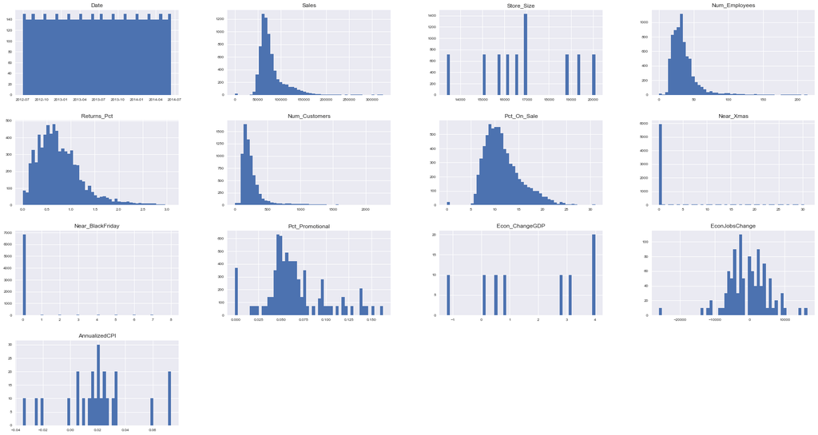

```python
# distribution of numerical variables
df.hist(figsize = (30, 16), bins = 50, xlabelsize = 8, ylabelsize = 8); # ; to remove verbose info
```

As a quick comparison among histograms of numerical variables, **Num_Employees**, **Returns_Pct**, **Num_Customers** and **Pct_On_Sale** show similar distributions as **Sales**, which could be good features in sales forecasting. Their association with **Sales** can be numerically calculated by correlation with **Sales**.

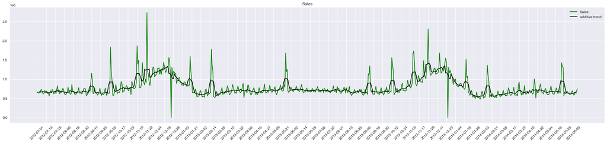

```python
time_series_plot(df_agg_date, "Sales")
```

From the aggregrated sales time series plot, the followings are noted:

- a trend with increasing slope around October to December
- a trend with decreasing slope around December to January
- weekly seasonality
- some irregular peaks and dips

```python
# where are the dips?
df_agg_date[df_agg_date['Sales'] == 0]
```

|  | Date | Sales | Store_Size | Num_Employees | Returns_Pct | Num_Customers | Pct_On_Sale | Near_Xmas | Near_BlackFriday | Pct_Promotional | Econ_ChangeGDP | EconJobsChange | AnnualizedCPI |
| --- | --- | --- | --- | --- | --- | --- | --- | --- | --- | --- | --- | --- | --- |
| 177 | 2012-12-25 | 0.0 | 169100 | 0 | 0.0 | 0 | 0.0 | 310 | 0 | 0.0 | 0.0 | 0.0 | 0.0 |
| 542 | 2013-12-25 | 0.0 | 169100 | 0 | 0.0 | 0 | 0.0 | 310 | 0 | 0.0 | 0.0 | 0.0 | 0.0 |

The two dips with zero sales happened on Dec 25.

If the number of such datapoints is limited (in this case the whole dataset last for less than 2 years, so there are just 2 such xmas data points), their values could be hard-coded instead of reply on predictions of forecast models.

```python
# correlation of numerical variables with Sales by descending order
df.corr()['Sales'].sort_values(ascending = False)
```

[output not shown]

```python
# data quality check: null values of each column
for col in df.columns:
    print(col, pd.isnull(df[col]).sum())
```

```
Store 0
Date 0
Sales 0
Store_Size 0
Num_Employees 0
Returns_Pct 0
Num_Customers 0
Pct_On_Sale 10
Marketing 0
Near_Xmas 0
Near_BlackFriday 0
Holiday 0
DestinationEvent 0
Pct_Promotional 0
Econ_ChangeGDP 7060
EconJobsChange 6120
AnnualizedCPI 6900
```

Since **Econ_ChangeGDP**, **EconJobsChange** and **AnnualizedCPI** contain large amount of missing values, also **Pct_Promotional** do not have significant correlation with sales, they will NOT be used in the forecasting exercise.

```python
# where are the null values of Pct_On_Sale coming from?
df[(df['Pct_On_Sale']).isnull()]
```

|  | Store | Date | Sales | Store_Size | Num_Employees | Returns_Pct | Num_Customers | Pct_On_Sale | Marketing | Near_Xmas | Near_BlackFriday | Holiday | DestinationEvent | Pct_Promotional | Econ_ChangeGDP | EconJobsChange | AnnualizedCPI |
| --- | --- | --- | --- | --- | --- | --- | --- | --- | --- | --- | --- | --- | --- | --- | --- | --- | --- |
| 658 | Louisville | 2014-04-20 | 60082.02 | 20100 | 16 | 0.19 | 0 | NaN | In Store Credit Card Signup Discount; Spring P... | 0 | 0 | No | No | 0.06616 | NaN | NaN | NaN |
| 1372 | Philadelphia | 2014-04-20 | 46927.63 | 15700 | 14 | 0.20 | 0 | NaN | In Store Credit Card Signup Discount; Spring P... | 0 | 0 | No | No | 0.06616 | NaN | NaN | NaN |
| 2086 | Detroit | 2014-04-20 | 49748.34 | 16600 | 16 | 0.19 | 0 | NaN | In Store Credit Card Signup Discount; Spring P... | 0 | 0 | No | No | 0.06616 | NaN | NaN | NaN |
| 2800 | Savannah | 2014-04-20 | 57812.73 | 19300 | 18 | 0.20 | 0 | NaN | In Store Credit Card Signup Discount; Spring P... | 0 | 0 | No | No | 0.06616 | NaN | NaN | NaN |
| 3514 | Portland | 2014-04-20 | 50392.12 | 16900 | 13 | 0.20 | 0 | NaN | In Store Credit Card Signup Discount; Spring P... | 0 | 0 | No | No | 0.06616 | NaN | NaN | NaN |
| 4228 | Columbus | 2014-04-20 | 48421.25 | 16200 | 16 | 0.18 | 0 | NaN | In Store Credit Card Signup Discount; Spring P... | 0 | 0 | No | No | 0.06616 | NaN | NaN | NaN |
| 4942 | Richmond | 2014-04-20 | 40073.29 | 13400 | 13 | 0.20 | 0 | NaN | In Store Credit Card Signup Discount; Spring P... | 0 | 0 | No | No | 0.06616 | NaN | NaN | NaN |
| 5656 | Lancaster | 2014-04-20 | 56239.30 | 18800 | 15 | 0.19 | 0 | NaN | In Store Credit Card Signup Discount; Spring P... | 0 | 0 | No | No | 0.06616 | NaN | NaN | NaN |
| 6370 | Baltimore | 2014-04-20 | 45223.00 | 15100 | 12 | 0.21 | 0 | NaN | In Store Credit Card Signup Discount; Spring P... | 0 | 0 | No | No | 0.06616 | NaN | NaN | NaN |
| 7084 | San Antonio | 2014-04-20 | 50738.16 | 17000 | 14 | 0.18 | 0 | NaN | In Store Credit Card Signup Discount; Spring P... | 0 | 0 | No | No | 0.06616 | NaN | NaN | NaN |

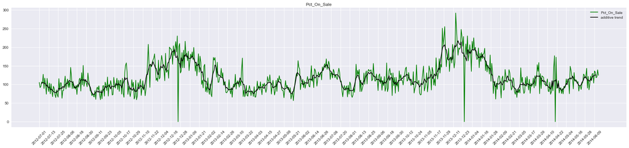

```python
time_series_plot(df_agg_date, "Pct_On_Sale")
```

Missing values of **Pct_On_Sale** are found only on 2014-04-20, where the number of customers were 0.

While other information is available on that day, it is assumed that 2014-04-20 is a normal day for sales operation.

Since **Pct_On_Sale** has a fairly high correlation with **Sales**, and **Sales** on 2014-04-20 was not 0, the missing values will be replaced by previous elements using the forward fill method `ffill()`.

```python
df['Pct_On_Sale'] = df['Pct_On_Sale'].ffill()
```

```python
# generate the dateset to aggregrate sum of Sales of all stores per Date again
df_agg_date = df.groupby('Date').agg('sum').sort_values(by = 'Date').reset_index()
```

[output not shown]

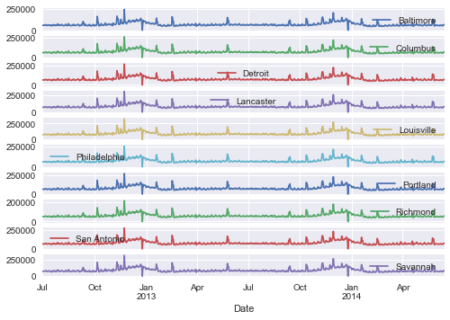

```python
# time series plot: Sales per Store
pd.pivot_table(df.reset_index(), index = 'Date', columns = 'Store', values = 'Sales').plot(subplots = True)
```

At the first glance, **Sales** among different stores exhibit similar shapes with same increasing & decreasing trends, peaks and dips around the same period.

### 1) Time Series Analysis

```python
def decompose_time_series(series, frequency):
    """
    Decompose a time series by given frequency

    Parameters:
    series: an array of data series
    frequency: target column of a dataframe to be displayed

    Return:
    a seasonal decomposition of time series additive trend as seasonal decomposition
    """
    mpl.style.use('seaborn')
    result = seasonal_decompose(series, model = 'additive', period = frequency)
    result.plot()
```

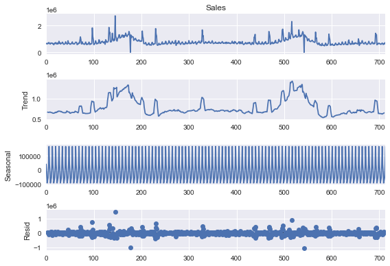

```python
# decomposition of sales of all stores per date frequency 7 as observed short term repeating pattern
decompose_time_series(df_agg_date['Sales'], 7)
```

### 2) Forecasting

```python
def train_test_split(data, date_filter):
    """
    Split data into train and test datasets by date_filter

    Parameters:
    data: input dataframe
    date_filter: the date to be split train and test sets

    Return:
    a training and testing datasets split by given date
    """
    training = data[data.Date < date_filter]
    testing = data[data.Date >= date_filter ]
    return training, testing
```

```python
# specify the variables of interest for modeling
all_variables_date = ['Sales', 'Date', 'Store_Size', 'Num_Employees', 'Pct_On_Sale', 'Near_Xmas', 'Near_BlackFriday'] # note the total Store_Size is the same for all stores per day
all_variables_date_store = ['Sales', 'Date', 'Store', 'Store_Size', 'Num_Employees', 'Pct_On_Sale', 'Near_Xmas', 'Near_BlackFriday']
target_variable = 'Sales'
```

```python
# specify the date to be split
date_split = '2014-05-16' # the period from 2014-05-16 to 2014-06-14 of 30D covers the a peak and a dip for model evaluation
```

```python
# split the total sales of all stores per date into train and test datasets
train_date = train_test_split(df_agg_date[all_variables_date], date_split)[0]
test_date = train_test_split(df_agg_date[all_variables_date], date_split)[1]

display_n(train_date, 2)
display_n(test_date, 2)
```

|  | Sales | Date | Store_Size | Num_Employees | Pct_On_Sale | Near_Xmas | Near_BlackFriday |
| --- | --- | --- | --- | --- | --- | --- | --- |
| 0 | 646521.78 | 2012-07-01 | 169100 | 342 | 105.26 | 0 | 0 |
| 1 | 664569.84 | 2012-07-02 | 169100 | 194 | 91.42 | 0 | 0 |
| ... | ... | ... | ... | ... | ... | ... | ... |
| 682 | 601561.39 | 2014-05-14 | 169100 | 246 | 131.87 | 0 | 0 |
| 683 | 668840.77 | 2014-05-15 | 169100 | 348 | 108.94 | 0 | 0 |

684 rows × 7 columns

|  | Sales | Date | Store_Size | Num_Employees | Pct_On_Sale | Near_Xmas | Near_BlackFriday |
| --- | --- | --- | --- | --- | --- | --- | --- |
| 684 | 703143.33 | 2014-05-16 | 169100 | 328 | 112.61 | 0 | 0 |
| 685 | 770988.64 | 2014-05-17 | 169100 | 321 | 110.89 | 0 | 0 |
| ... | ... | ... | ... | ... | ... | ... | ... |
| 712 | 710997.99 | 2014-06-13 | 169100 | 351 | 139.30 | 0 | 0 |
| 713 | 744773.73 | 2014-06-14 | 169100 | 349 | 124.52 | 0 | 0 |

30 rows × 7 columns

```python
# split the sales per date into train and test datasets
train_date_store = train_test_split(df[all_variables_date_store], date_split)[0]
test_date_store = train_test_split(df[all_variables_date_store], date_split)[1]

display_n(train_date_store, 2)
display_n(test_date_store, 2)
```

|  | Sales | Date | Store | Store_Size | Num_Employees | Pct_On_Sale | Near_Xmas | Near_BlackFriday |
| --- | --- | --- | --- | --- | --- | --- | --- | --- |
| 0 | 76819.40 | 2012-07-01 | Louisville | 20100 | 42 | 9.96 | 0 | 0 |
| 1 | 78963.86 | 2012-07-02 | Louisville | 20100 | 21 | 8.65 | 0 | 0 |
| ... | ... | ... | ... | ... | ... | ... | ... | ... |
| 7108 | 60361.21 | 2014-05-14 | San Antonio | 17000 | 26 | 13.66 | 0 | 0 |
| 7109 | 67112.08 | 2014-05-15 | San Antonio | 17000 | 37 | 11.29 | 0 | 0 |

6840 rows × 8 columns

|  | Sales | Date | Store | Store_Size | Num_Employees | Pct_On_Sale | Near_Xmas | Near_BlackFriday |
| --- | --- | --- | --- | --- | --- | --- | --- | --- |
| 684 | 83547.14 | 2014-05-16 | Louisville | 20100 | 34 | 10.65 | 0 | 0 |
| 685 | 91608.49 | 2014-05-17 | Louisville | 20100 | 34 | 10.49 | 0 | 0 |
| ... | ... | ... | ... | ... | ... | ... | ... | ... |
| 7138 | 71342.17 | 2014-06-13 | San Antonio | 17000 | 35 | 14.43 | 0 | 0 |
| 7139 | 74731.26 | 2014-06-14 | San Antonio | 17000 | 34 | 12.90 | 0 | 0 |

300 rows × 8 columns

With the underlying statistical assumptions,the Autoregressive Integrated Moving Average (ARIMA) model provides a good starting point in time series forecasting. It is a linear combination of Auto-Regressive (lag(s) of target variable) AR terms, Moving Averages (lag(s) of forecast errors) MA terms and differencing I term, when the process is non-stationary. The parameters p, d, q in the ARIMA(p, d, q) model are:

- p: the number of autoregressive terms
- d: the number of differencing
- q: the number of lagged forecast error terms

Akaike Information Criterion (AIC) is used to estimate the quality of each ARIMA model relative to each of other models, which provides a means for model selection. AIC is calcuated from the number of independent variables used to build the model, and the maximum likelihood estimate of the model, that is how well the model reproduces the data. The best-fit ARIMA model according to AIC is the one which explains the greatest amount of variation using the fewest possible independent variables. Therefore the lower the AIC value, the better the model.

```python
# determine the necessity of time differencing using Augmented Dickey-Fuller unit root test
adf_test_result = adfuller(df_agg_date["Sales"])
print('ADF Statistic: %f' % adf_test_result[0])
print('p-value: %f' % adf_test_result[1])
print('Critical Values:')
for key, value in adf_test_result[4].items():
  print('\t%s: %.3f' % (key, value))
```

```
ADF Statistic: -2.685905
p-value: 0.076509
Critical Values:
	1%: -3.440
	5%: -2.866
	10%: -2.569
```

Since the p-value 0.0765 is between 0.05 and 0.1, the ADF Statistic -2.686 is closer to Critical Values at 10% (-2.569). The Null-hypothesis of ADF-test that the process has an unit root can be rejected at 10% confidence level, therefore the process is stationary and time differencing for stationarity is NOT necessary.

```python
def best_arima_by_aic(dataframe, tar_var, exog_var):
    """
    automatically determine parameters of ARIMA model

    Parameters:
    dataframe: input dataframe
    tar_var: target variable of input dataframe
    exog_var: exogenous variable(s) of input dataframe

    Return:
    best parameters p and q of ARIMA model by least aic values
    """
    best_aic = 1000000 # initiate a very large best_aic value
    for p in range(8):
        for q in range(8):
            model = ARIMA(dataframe[tar_var], order = (p, 0, q), exog = dataframe[exog_var]) # stationary process: d = 0
            model_fit = model.fit()
            print("p: ", p, "q: ", q, "; AIC: ", model_fit.aic)
            if model_fit.aic < best_aic:
                best_aic = model_fit.aic
                best_model = model_fit
                best_p = p
                best_q = q
    return best_p, best_q
```

```python
best_arima_by_aic(train_date, 'Sales', ['Num_Employees', 'Pct_On_Sale', 'Near_Xmas', 'Near_BlackFriday'])
```

```
p:  0 q:  0 ; AIC:  21877.273847928864
p:  0 q:  1 ; AIC:  18061.7131680143
p:  0 q:  2 ; AIC:  18039.036743520228
p:  0 q:  3 ; AIC:  18032.365626622697
p:  0 q:  4 ; AIC:  18024.00870642523
p:  0 q:  5 ; AIC:  18024.31326623605
p:  0 q:  6 ; AIC:  18026.32380689196
p:  0 q:  7 ; AIC:  18000.496098605196
p:  1 q:  0 ; AIC:  18046.477881116876
p:  1 q:  1 ; AIC:  17985.84745114261
p:  1 q:  2 ; AIC:  17988.74427937005
p:  1 q:  3 ; AIC:  17990.067307893074
p:  1 q:  4 ; AIC:  17991.822931739367
p:  1 q:  5 ; AIC:  17994.15789153926
p:  1 q:  6 ; AIC:  17994.74028723812
p:  1 q:  7 ; AIC:  17986.804694317427
p:  2 q:  0 ; AIC:  18019.262070670764
p:  2 q:  1 ; AIC:  17987.768272898284
p:  2 q:  2 ; AIC:  17989.310986157427
p:  2 q:  3 ; AIC:  17991.610139887925
p:  2 q:  4 ; AIC:  17990.503794038377
p:  2 q:  5 ; AIC:  17989.862667679663
p:  2 q:  6 ; AIC:  17990.866596750675
p:  2 q:  7 ; AIC:  17982.981999674867
p:  3 q:  0 ; AIC:  18013.36232338167
p:  3 q:  1 ; AIC:  17990.60441476977
p:  3 q:  2 ; AIC:  17990.375891832584
p:  3 q:  3 ; AIC:  17958.00579071229
p:  3 q:  4 ; AIC:  17979.431070840823
p:  3 q:  5 ; AIC:  17958.60185062691
p:  3 q:  6 ; AIC:  17961.922706036057
p:  3 q:  7 ; AIC:  17984.770142125664
p:  4 q:  0 ; AIC:  18005.4754020276
p:  4 q:  1 ; AIC:  17990.061099053804
p:  4 q:  2 ; AIC:  17988.594539248763
p:  4 q:  3 ; AIC:  17979.29062427416
p:  4 q:  4 ; AIC:  17982.655626912987
p:  4 q:  5 ; AIC:  17962.38217962868
p:  4 q:  6 ; AIC:  17975.821397342843
p:  4 q:  7 ; AIC:  17977.063930534736
```

[output cut: 9 more lines]

```
p:  6 q:  1 ; AIC:  17994.304429146454
p:  6 q:  2 ; AIC:  17989.516269572712
p:  6 q:  3 ; AIC:  17996.17155148877
p:  6 q:  4 ; AIC:  17974.4978186835
p:  6 q:  5 ; AIC:  17963.93920293656
p:  6 q:  6 ; AIC:  17969.236692967956
p:  6 q:  7 ; AIC:  17971.610179469397
p:  7 q:  0 ; AIC:  17975.596771524808
p:  7 q:  1 ; AIC:  17977.45814532421
p:  7 q:  2 ; AIC:  17976.516728586303
p:  7 q:  3 ; AIC:  17978.078460049062
p:  7 q:  4 ; AIC:  17972.054783426174
p:  7 q:  5 ; AIC:  17937.43072846082
p:  7 q:  6 ; AIC:  17972.431383307336
p:  7 q:  7 ; AIC:  17921.368066191353
```

```
(7, 7)
```

```python
# based on the automatic determination of parameters in ARIMA model to implement forecasting model by rolling the training periods
def rolling_forecasting_result(step, training, testing, target_var):
    """
    apply the rolling ARIMA model results on next element of test set

    Parameters:
    step: period between training and testing datasets
    training: initial input training dataset used for training
    testing: initial input testing dataset used for testing
    target_var: input target variable

    Return:
    df and summary as model and business evaluation metrics
    """
    train_series = pd.Series.tolist(training[target_var])
    test_series = pd.Series.tolist(testing[target_var])
    time_series = pd.Series.tolist(testing.Date)
    predictions = list()
    dt = []
    for t in range(len(test_series)):
        model = ARIMA(train_series, order = (7, 0, 7)) # exog variables were not applied due to memory runout
        model_fit = model.fit()
        output = model_fit.forecast()
        yhat = output[0]
        predictions.append(yhat)
        obs = test_series[t - step]
        train_series.append(obs)
        dt.append([time_series[t],
                   yhat,
                   test_series[t],
                  test_series[t] - yhat,
                  1 - abs(test_series[t] - yhat)/test_series[t],
                  (test_series[t] - yhat)/abs(test_series[t] - yhat),
                  abs(test_series[t] - yhat)/test_series[t]])
        df = pd.DataFrame(dt)
        df.columns = ['Date', 'Sales_Forecast', 'Actual_Sales', 'Forecast_Error', 'Forecast_Accuracy', 'Tracking_Signal', 'Error_Ratio']
    bias = df[['Forecast_Error']].mean()
    tracking_signal = df[['Tracking_Signal']].sum()
    mae = abs(df[['Forecast_Error']]).mean()
    mape = df[['Error_Ratio']].mean()
    mse = mean_squared_error(test_series, predictions)
    rmse = sqrt(mean_squared_error(test_series, predictions))
    summary = {'bias': bias,
               'sum_tracking_signal': tracking_signal,
               'mean_average_error': mae,
               'mean_average_percentage_error': mape,
               'mean_square_error': mse,
               'root_mean_square_error': rmse}
    return df, summary
```

```python
best_arima_by_aic(train_date_store, 'Sales', ['Store_Size', 'Num_Employees', 'Pct_On_Sale', 'Near_Xmas', 'Near_BlackFriday'])
```

```
p:  0 q:  0 ; AIC:  203623.09513726633
p:  0 q:  1 ; AIC:  149693.4705649393
p:  0 q:  2 ; AIC:  149439.50939412203
p:  0 q:  3 ; AIC:  149355.88246347592
p:  0 q:  4 ; AIC:  149246.44993419954
p:  0 q:  5 ; AIC:  149228.56103088925
p:  0 q:  6 ; AIC:  149227.67334691517
p:  0 q:  7 ; AIC:  148999.35269927105
p:  1 q:  0 ; AIC:  149533.87171403447
p:  1 q:  1 ; AIC:  148915.58770614403
p:  1 q:  2 ; AIC:  148912.52084826241
p:  1 q:  3 ; AIC:  148926.64796368446
p:  1 q:  4 ; AIC:  148924.06971599776
p:  1 q:  5 ; AIC:  148925.35489184308
p:  1 q:  6 ; AIC:  148914.45325875137
p:  1 q:  7 ; AIC:  148844.7884650728
p:  2 q:  0 ; AIC:  149241.66702348174
p:  2 q:  1 ; AIC:  148915.3844360577
p:  2 q:  2 ; AIC:  148915.15897876816
p:  2 q:  3 ; AIC:  148896.6632413709
p:  2 q:  4 ; AIC:  148903.7083753809
p:  2 q:  5 ; AIC:  148865.26482696872
p:  2 q:  6 ; AIC:  148871.22388294718
p:  2 q:  7 ; AIC:  148795.26492879854
p:  3 q:  0 ; AIC:  149169.66142359705
p:  3 q:  1 ; AIC:  148906.9480375349
p:  3 q:  2 ; AIC:  148926.03793365855
p:  3 q:  3 ; AIC:  148637.7115573406
p:  3 q:  4 ; AIC:  148820.8333289966
p:  3 q:  5 ; AIC:  148593.0197231153
p:  3 q:  6 ; AIC:  148579.94235808036
p:  3 q:  7 ; AIC:  148796.36964946365
p:  4 q:  0 ; AIC:  149073.15176993626
p:  4 q:  1 ; AIC:  148898.50322110645
p:  4 q:  2 ; AIC:  148886.5298709989
p:  4 q:  3 ; AIC:  148825.42158051848
p:  4 q:  4 ; AIC:  148912.01307923108
p:  4 q:  5 ; AIC:  148601.2757596485
p:  4 q:  6 ; AIC:  148741.3788387024
p:  4 q:  7 ; AIC:  148724.11741752762
```

[output cut: 9 more lines]

```
p:  6 q:  1 ; AIC:  148919.10814233113
p:  6 q:  2 ; AIC:  148847.1801439114
p:  6 q:  3 ; AIC:  148794.8789059844
p:  6 q:  4 ; AIC:  148745.19697704082
p:  6 q:  5 ; AIC:  148570.11833256346
p:  6 q:  6 ; AIC:  148687.4217265949
p:  6 q:  7 ; AIC:  148577.2418131529
p:  7 q:  0 ; AIC:  148779.16409716936
p:  7 q:  1 ; AIC:  148780.73171928967
p:  7 q:  2 ; AIC:  148753.89518621913
p:  7 q:  3 ; AIC:  148754.90719528316
p:  7 q:  4 ; AIC:  148687.0119460802
p:  7 q:  5 ; AIC:  148687.62893466937
p:  7 q:  6 ; AIC:  148524.18656872012
p:  7 q:  7 ; AIC:  148248.00554584086
```

```
(7, 7)
```

```python
result_table_date = rolling_forecasting_result(step = 1, training = train_date, testing = test_date, target_var = target_variable)
```

```python
result_table_date = rolling_forecasting_result(step = 1, training = train_date_store, testing = test_date_store, target_var = target_variable) # sales forecast by store and date is still running before submission
```

```python
def plot_forecast_vs_actual(tbl):
    """
    visualise a forecast again actual sales

    Parameters:
    tbl: input test dataset

    Return:
    time series Sales Forecast against Actual Sales
    """
    tbl = tbl.set_index('Date')
    plt.figure(figsize = (30, 6))
    mpl.style.use('seaborn')

    plt.plot(tbl[['Actual_Sales']],'-g', label = 'Actual Sales')
    plt.plot(tbl[['Sales_Forecast']],'-r', label='Sales Forecast')
    plt.xticks(tbl.index[::2], rotation = 45)
    plt.title('Sales Forecast vs Actual Sales')

    plt.legend()
```

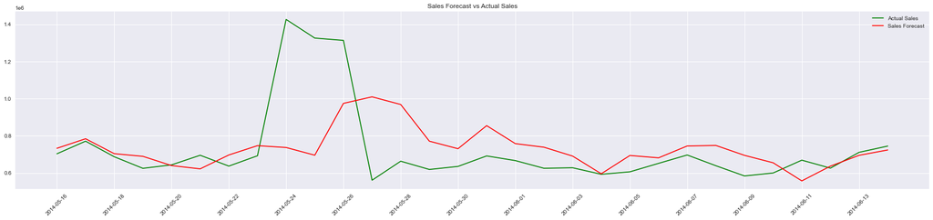

```python
plot_forecast_vs_actual(result_table_date[0])
```

```python
result_table_date[0]
```

|  | Date | Sales_Forecast | Actual_Sales | Forecast_Error | Forecast_Accuracy | Tracking_Signal | Error_Ratio |
| --- | --- | --- | --- | --- | --- | --- | --- |
| 0 | 2014-05-16 | 7.327208e+05 | 703143.33 | -29577.458650 | 0.957935 | -1.0 | 0.042065 |
| 1 | 2014-05-17 | 7.840307e+05 | 770988.64 | -13042.075492 | 0.983084 | -1.0 | 0.016916 |
| 2 | 2014-05-18 | 7.037776e+05 | 687272.09 | -16505.482081 | 0.975984 | -1.0 | 0.024016 |
| 3 | 2014-05-19 | 6.895092e+05 | 624918.06 | -64591.111871 | 0.896641 | -1.0 | 0.103359 |
| 4 | 2014-05-20 | 6.397250e+05 | 643529.65 | 3804.663974 | 0.994088 | 1.0 | 0.005912 |
| 5 | 2014-05-21 | 6.221077e+05 | 695308.96 | 73201.235460 | 0.894721 | 1.0 | 0.105279 |
| 6 | 2014-05-22 | 6.967431e+05 | 636914.18 | -59828.905161 | 0.906064 | -1.0 | 0.093936 |
| 7 | 2014-05-23 | 7.469379e+05 | 692557.99 | -54379.944820 | 0.921480 | -1.0 | 0.078520 |
| 8 | 2014-05-24 | 7.370042e+05 | 1426090.07 | 689085.873319 | 0.516801 | 1.0 | 0.483199 |
| 9 | 2014-05-25 | 6.955067e+05 | 1325779.71 | 630273.057886 | 0.524602 | 1.0 | 0.475398 |
| 10 | 2014-05-26 | 9.743581e+05 | 1313356.87 | 338998.725836 | 0.741884 | 1.0 | 0.258116 |
| 11 | 2014-05-27 | 1.009585e+06 | 560944.01 | -448641.213520 | 0.200203 | -1.0 | 0.799797 |
| 12 | 2014-05-28 | 9.683646e+05 | 663215.62 | -305148.961933 | 0.539895 | -1.0 | 0.460105 |
| 13 | 2014-05-29 | 7.709411e+05 | 618834.73 | -152106.331341 | 0.754205 | -1.0 | 0.245795 |
| 14 | 2014-05-30 | 7.305249e+05 | 635226.95 | -95297.938359 | 0.849978 | -1.0 | 0.150022 |
| 15 | 2014-05-31 | 8.546495e+05 | 691679.83 | -162969.674308 | 0.764386 | -1.0 | 0.235614 |
| 16 | 2014-06-01 | 7.578794e+05 | 666538.32 | -91341.064700 | 0.862962 | -1.0 | 0.137038 |
| 17 | 2014-06-02 | 7.385688e+05 | 625215.31 | -113353.494450 | 0.818697 | -1.0 | 0.181303 |
| 18 | 2014-06-03 | 6.907790e+05 | 628015.08 | -62763.870547 | 0.900060 | -1.0 | 0.099940 |
| 19 | 2014-06-04 | 5.957039e+05 | 592786.06 | -2917.800847 | 0.995078 | -1.0 | 0.004922 |
| 20 | 2014-06-05 | 6.941493e+05 | 606123.81 | -88025.531270 | 0.854773 | -1.0 | 0.145227 |
| 21 | 2014-06-06 | 6.813705e+05 | 651625.49 | -29744.965475 | 0.954353 | -1.0 | 0.045647 |
| 22 | 2014-06-07 | 7.452392e+05 | 696714.41 | -48524.752055 | 0.930352 | -1.0 | 0.069648 |
| 23 | 2014-06-08 | 7.481015e+05 | 638985.62 | -109115.832585 | 0.829236 | -1.0 | 0.170764 |
| 24 | 2014-06-09 | 6.947887e+05 | 583877.30 | -110911.374822 | 0.810043 | -1.0 | 0.189957 |
| 25 | 2014-06-10 | 6.547883e+05 | 599840.36 | -54947.973768 | 0.908396 | -1.0 | 0.091604 |
| 26 | 2014-06-11 | 5.572819e+05 | 668802.12 | 111520.210752 | 0.833254 | 1.0 | 0.166746 |
| 27 | 2014-06-12 | 6.367651e+05 | 625992.46 | -10772.605895 | 0.982791 | -1.0 | 0.017209 |
| 28 | 2014-06-13 | 6.949090e+05 | 710997.99 | 16088.979794 | 0.977371 | 1.0 | 0.022629 |
| 29 | 2014-06-14 | 7.236803e+05 | 744773.73 | 21093.434014 | 0.971678 | 1.0 | 0.028322 |

```python
result_table_date[0][['Forecast_Accuracy']].mean()
```

```
Forecast_Accuracy    0.835033
dtype: float64
```

```python
result_table_date[1]
```

```
{'bias': Forecast_Error   -8014.73943
 dtype: float64,
 'sum_tracking_signal': Tracking_Signal   -14.0
 dtype: float64,
 'mean_average_error': Forecast_Error    133619.151499
 dtype: float64,
 'mean_average_percentage_error': Error_Ratio    0.164967
 dtype: float64,
 'mean_square_error': 47806197325.71336,
 'root_mean_square_error': 218646.2835854142}
```

### 3) Conclusion & Business Insights

The following KPIs are used in the forecast evaluation. For each single day in the test set,

- **Forecast Error** measures how the forecast sales deviated from actual sales.
- **Forecast Accuracy** tells how accurate sales has been forecasted. The better the forecast accuracy, the more aligned the operational costs are and the higher the profits.
- **Tracking Signal** measures the existence of persistent bias. For one period it is either 1 which indicates under-forecasting (actual sales is higher than forecast) or -1 which indicates over-forecasting (actual sales is lower than forecasting).
- **Error Ratio** measures how inaccurate the sales has been forecasted.

Forecast Accuracy will be the main KPI to monitor the business performance based on the forecast model. The Forecast Accuracy of forecast with cold-start is around 70-80%. 90% is considered to be a good forecast.

In this forecasting exercise - Sales Forecast per day, Forecast Accuracy is on average 84%. As observed graphically the peaks between 2014-05-24 and 2014-05-26 and the dip on 2014-05-27 were not captured in the model, which reduce the forecast accuracy. This should be targeted as the next improvement trial.

As a summary of forecast across all observations in a test period,

- **bias** is measured as mean forecast error, shows the tendency for forecast errors to trend in one direction.
- **sum_tracking_signal** indicates the overall existence of persistent bias.
- **mean_average_error** measures forecast accuracy by averaging the magnitudes of the forecast errors and thereby revealing the variability of forecasts over time.
- **mean_average_percentage_error** expresses the degree of error as a percentage.
- **mean_square_error** evaluates forecast performance by averaging the squares of the forecast errors, which removes all negative terms.
- **root_mean_square_error** is defined as the square root of the average squared error, which gives the same unit in comparison to mean square error.

In this forecasting exercise, the over tracking signal is negative, which indicates there is an over-forecasting in general. Mean average percentage error is around 16%, which is another way for measure forecast accuracy.

In the determination of parameters of ARIMA(p, d, q) model, both endogenous (variables explained by ARIMA model) and exogenous (variables not explained by ARIMA model) variables are used. In the above forecasting implementation, ARIMA model is applied on endogeneous variable only due to memory limitation before assignment submittion.

In the current stage, some existing variables like the text in **Marketing**, **Holiday** and **Destination Event** are not used. They could contain signals in sales forecasting.

In the current stage no feature engineering is applied. As the training data accumulates, variation of date features among months or years can provide signals on forecasting, e.g.:

- around month end or start people are more likely to consume after salary payment
- every xmas on Dec 25 the store are closed and hence with no sales (which can also be hard coded)

Currently the economic variables are not considered due to large number of missing values and low correlation with sales. Sometimes economic variables are useful for sales forecasting when their lag values have effects on sales at later time points. This could be further studied in the next trial.

In order to improve forecast, additional features which are not included in the dataset can also be considered, for instance:

- weather information of individual stores location
- substitute product information
- competitor information

### 4) Scalability & Productization

Solution deployment

- **Streamlit** In our prototyping in Python and experimentation in scripts, the forecasting model can be quickly deployed with Streamlit as data prototyping application building with user interface.
- **Cloud** Cloud services are another alternative, if the underlying computation varies along the day which the cloud services take care with the cluster management.

In order to maintain the model in production so that it is robost to changes in project requirements, the following procedures can be considered:

- **Code Refactoring in modular form** Putting code into modular form is easier to maintain, test and debug.
- **Model monitoring** Model monitoring is crucial, since there will be data or model drift as time goes, such that the old model is not valid for the upcoming / new data anymore. In this case, model retraining is required and can be scheduled periodically or upon triggers in monitoring.
- **Model training management** In case of data size increment due to additional features or training data as time goes, training can be conducted in the cloud with auto-scale cluster management.